# R Project Milestone 6

Moyra Rasheed, Courtney Coon, Jarett Maycott

2022-11-28

# **Problem Statement**

Rural hospitals are struggling to stay open throughout the country and the state of California ranks #4 in rural hospital closures ([citation](https://kesq.com/stacker-california/2021/12/09/california-is-the-4-state-with-the-most-rural-hospital-closures-since-2005/)). When rural hospitals close, there is a subsequent rise in mortality ([citation](https://www.nber.org/papers/w26182?utm_campaign=ntwh&utm_medium=email&utm_source=ntwg12)). This is why the California Department of Public Health, Office of Health Equity is excited that a new policy has just been created to fund a public-private partnership for healthcare facility improvement in 5 of California’s rural counties that have received minimal funding from the Department of Health Care Access and Information (HCAI) over the past 5 years. Here we have analyzed 5 variables in order to determine which 5 counties are the best targets for the development fund proposals.

# **Methods**

### **Data Sources**

To make recommendations on target counties, we used variables from three open-access, State of California data sources which are described below.

#### *[California demographics by County](https://github.com/PHW290/phw251_projectdata/blob/main/ca_county_demographic.csv)*

Includes data on population characteristics by county including average population density, counts by race/ethnicity, sex, median age, and housing data.

**Years and/or dates of data**

Data was collected in 2012.

**Description of cleaning and creating new variables**

To prepare the data, we:

1. Data cleaning
- make “County” the first (left-most) column in the data set for merging
2. Data filtering
- we subset data to only include needed data: “pop2012”,“pop12_sqmi”, “name”, “med_age”,“renter_occ”, “owner_occ”
3. Data summarizing
- *NEW VARIABLE*: categorize Median Age into “High Priority” (counties with Median Age above the third quantile), “Medium Priority” (counties with Median Age between the first and third quantiles), and “Low Priority” (counties with Median Age below the first quantile)
- *NEW VARIABLE*: categorize Population per Square Mile (hereafter Population Density) into “High Priority” (counties with Population Density above the third quantile), “Medium Priority” (counties with Population Density between the first and third quantiles), and “Low Priority” (counties with Population Density below the first quantile)
- *NEW VARIABLE*: create ratio of renting households as a fraction of total households.
- *NEW VARIABLE*: categorize Percent of Household that were Renters (hereafter Percent Renters) into “High Priority” (counties with Percent Renters above the third quantile), “Medium Priority” (counties with Percent Renters between the first and third quantiles), and “Low Priority” (counties with Percent Renters below the first quantile)

#### *[California Department of Public Health Care: Death Profiles by County](https://data.ca.gov/dataset/death-profiles-by-county)*

Includes data on mortality events stratified by age, sex, race, hospital department, and residence status of the deceases relative to the hospital where the mortality event occurred.

**Years and/or dates of data**

The data set contains data from 2014 through 2020, though the data was restricted to data from 2015 through 2020 to correspond with requirement that the data used in this analysis was collected over the most recent 5 years.

**Description of cleaning and creating new variables**

#### *[Department of Health Care Access and Information: Total Construction Cost of Healthcare Projects](https://data.ca.gov/dataset/total-construction-cost-of-healthcare-projects)*

Includes number of projects and total spending on hospital projects funded by Department of Health Care Access and Information (HCAI) by county, date, and project status (“in review”, “pending construction”, “in construction” and “in closure.”)

**Years and/or dates of data**

The data set contains data from 10-14-2013 through 08-11-2022, though the data was restricted to 5 years from 2015 through 2020 to correspond with data availability in the other data sets.

**Description of cleaning and creating new variables**

### **Analytic methods**

We decided to approach the ranking of counties with two different techniques to examine the robustness of our final recommendations. Our first approach was to use to two graphs. In the first graph would be a scatterplot where we would use just the 3 demographic variables to identify top priority counties with fraction of renters on the x-axis, median age of the residents on the y-axis and dots to color code populations as being high or low priority based on population density (lower density was higher priority).

To prepare for our second scatterplot, we collapsed the ranking data from the first scatterplot into a single data set by coding a *NEW VARIABLE* where we gave 2 points to variables identified as “high priority,” 1 point for variables identified as “medium priority” and zero points for “low priority” variables for each county. For example, Amador County is a high priority population based on median age (2 points) and population density (2 more points) but a low priority population based on proportion of residents that were renters (0 points) for a total demographic ranking score of 4 points. This 6th variable was used to color code the dots in the second scatterplot where we had Total Cost of Previous and Ongoing OSHPD/HCAI project on the x-axis and Relative Levels of Chronic Disease Mortality Events on the y-axis. This second graph highlights the counties that we would consider recommending for future priority funding because it includes all 5 variables of interest.

Our second approach was to use a table with a *NEW VARIABLE* to rank the counties on all 5 variables of interest simultaneously. The ranking variable uses the same method that was previously explained but for all 5 variables instead of just the 3 demographic variables: 2 points were given to variables identified as “high priority,” 1 point for variables identified as “medium priority” and zero points for “low priority” variables for each county. For example, Siskiyou County is a high priority population based on median age (2 points), population density (2 more points) and relative chronic disease mortality (additional 2 points). It was a medium priority population based on total previous OSHPD/HCAI funding (1 point) and a low priority population based on proportion of residents that were renters (0 points) for a total ranking score of 7 points. Counties were then ranked on their total ranking score.

# **Results**

### *Figure 1:*

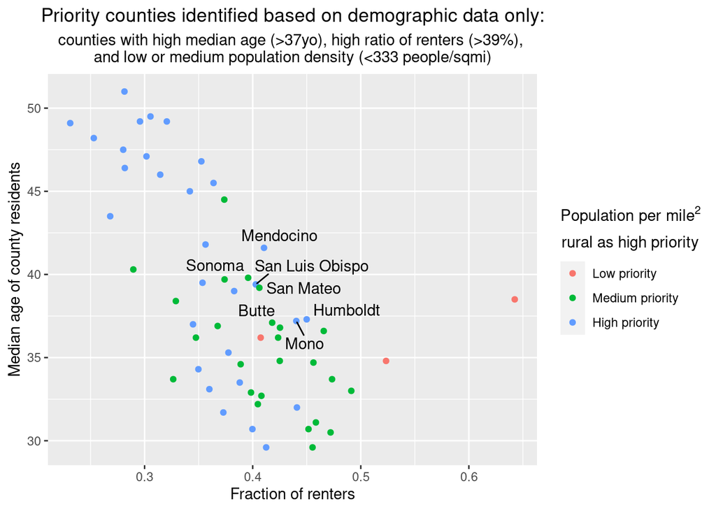

### *Figure 2:*

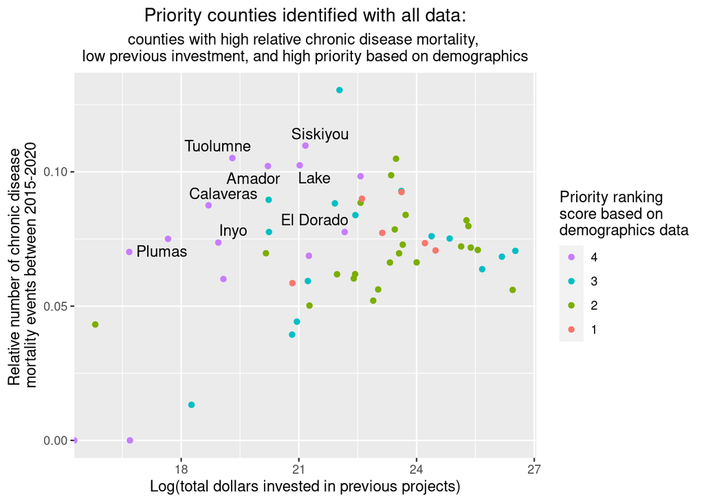

### *Table:*

```
## # A tibble: 15 × 12
##    county    summed_total_cost pop12_sqmi med_age renter_ratio relative_chronic…
##    <chr>                 <dbl>      <dbl>   <dbl>        <dbl>             <dbl>
##  1 Amador           598970736.      63.3     48.2        0.253            0.102
##  2 Calaveras        131848234.      44.6     49.1        0.231            0.0875
##  3 Tuolumne         242129946       24.3     47.1        0.302            0.105
##  4 Inyo             169160700.       1.82    45.5        0.364            0.0737
##  5 Lake            1347450993.      49.1     45          0.342            0.102
##  6 Mariposa          17474756       12.6     49.2        0.321            0.0702
##  7 Nevada          6352716267.     103.      47.5        0.280            0.0984
##  8 Plumas            46955168        7.65    49.5        0.305            0.0750
##  9 Siskiyou        1558949981.       7.12    46.8        0.353            0.110
## 10 Tehama           610226591.      21.5     39.5        0.354            0.0896
## 11 Alpine                   0        1.54    46.4        0.282            0
## 12 Del Norte        615640530.      28.3     39          0.383            0.0776
## 13 El Dorado       4239088028.     102.      43.5        0.268            0.0776
## 14 Humboldt       17981394511.      38.1     37.3        0.450            0.0929
## 15 Modoc           1703663257        2.33    46          0.314            0.0687
## # … with 6 more variables: med_age_CAT <fct>, summed_total_cost_CAT <fct>,
## #   pop12_sqmi_CAT <fct>, renter_ratio_CAT <chr>,
## #   relative_chronic_dis_mort_CAT <fct>, temp_rank <dbl>
```

# **Discussion**

Table 1: We used a table as a different way to organize the 5 variables of interest. We categorized each variable and then ranked each as high, medium, or low priority. We then created a new variable where “high priority” variables were given two points, “medium priority” variables given 1 point, and “low priority” variables given 0 points for each county. Then Counties are ranked by number of points. Most of the Counties highlighted in Plot/Visualization 2 were also the most highly ranked in the table.